# Follow: RNA-seq data analysis with DESeq2

Jingyi Tang

10/16/2020

The original post of the workshop can be found [here](https://bioconductor.github.io/BiocWorkshops/rna-seq-data-analysis-with-deseq2.html).

# Overview

A quick overview of the most useful functions in the DESeq2 package, and a basic RNA-seq analysis

- how to quantify transcript expression from FASTQ files using Salmon
- import quantification from Salmon with tximport and tximeta
- generate plots for quality control and exploratory data analysis EDA (also using MultiQC)
- perform differential expression (DE) (also using apeglm)
- overlap with other experimental data (using AnnotationHub)
- build reports (using ReportingTools and Glimma).
- a short example of integration of DESeq2 with the zinbwave package for single-cell RNA-seq differential expression

## Goals and Objectives

**Learning goals**

- Visually assess quality of RNA-seq data
- Perform basic differential analysis of RNA-seq data
- Compare RNA-seq results with other experimental data

**Learning objectives**

- Quantify transcript expression from FASTQ files
- Import quantification into R/Bioconductor
- Perform quality control and exploratory data analysis
- Perform differential expression
- Overlap with other experimental data
- Build dynamic reports
- Integrate DESeq2 and zinbwave for single-cell RNA-seq data

# Preparing data for DESeq2

## Experimental data

The data used in this workflow is stored in the *airway* package.

**Takeaways:**

- airway smooth muscle cells treated with dexamethasone
  - Dexamethasone: a synthetic glucocorticoid steroid with anti-inflammatory effects
    - Glucocorticoids are used by people with asthma to reduce inflammation of the airways
- In this experiment:
  - 4 primary human airway smooth muscle cell lines
  - treated with 1 micromolar dexamethasone for 18 hours
  - For each of the four cell lines
    - 1 treated sample
    - 1 untreated sample
1. import RNA-seq quantification data using an alternative dataset (the *tximportData* package which is used in the *tximport* vignette)
2. load counts for the airway dataset, which were counted using *summarizeOverlaps* from the *GenomicAlignments* package

GAP: recommend the *tximport* pipeline for producing count matrices, but we do not yet have a Bioconductor package containing the necessary quantification files for the airway dataset

## Modeling count data

The **count-based statistical methods**, such as *DESeq2* (Love, Huber, and Anders 2014), *edgeR* (Robinson, McCarthy, and Smyth 2009), *limma* with the voom method (Law et al. 2014), *DSS* (Wu, Wang, and Wu 2013), *EBSeq* (Leng et al. 2013) and *baySeq* (Hardcastle and Kelly 2010), expect input data as obtained, e.g., from RNA-seq or another high-throughput sequencing experiment, in the form of a **matrix of counts**.

The value in the **i-th row** and the **j-th column** of the matrix tells how many reads (or fragments, for paired-end RNA-seq) have been assigned to **gene i** in **sample j**.

| gene # | sample 1 | sample 2 | … | sample j |
| --- | --- | --- | --- | --- |
| $gene_1$ | $x_{11}$ | $x_{12}$ | … | $x_{1j}$ |
| $gene_2$ | $x_{21}$ | $x_{22}$ | … | $x_{2j}$ |
| $gene_3$ | $x_{31}$ | $x_{32}$ | … | $x_{3j}$ |
| … | … | … | … | … |
| $gene_{i-1}$ | $x_{i-1,1}$ | $x_{i-1,2}$ | … | $x_{i-1,j}$ |
| $gene_i$ | $x_{i1}$ | $x_{i2}$ | … | $x_{ij}$ |

- The values in the matrix should be counts of sequencing reads/fragments.
- This is important for the statistical models used by DESeq2 and edgeR to hold, as only counts allow assessing the measurement precision correctly.
- It is important to not provide counts that were pre-normalized for sequencing depth (also called library size), as the statistical model is most powerful when applied to un-normalized counts and is designed to account for library size differences internally.

Analogously, for other types of assays[试验], the **rows of the matrix** might correspond e.g., to **binding regions** (with ChIP-Seq), **species of bacteria** (with metagenomic datasets), or **peptide sequences** (with quantitative mass spectrometry).

## Transcript abundances

In this workflow, the shown method is how to use transcript abundances as quantified by the [Salmon](https://combine-lab.github.io/salmon/) (Patro et al. 2017) software package. Salmon and similar packages estimate the relative abundances of all (known, annotated) transcripts without aligning reads. Because estimating the abundance of the transcripts involves an inference step, the counts are *estimated*. Most methods either use a statistical framework called Estimation-Maximization or Bayesian techniques to estimate the abundances and counts.

Following quantification, we will use the tximport (Soneson, Love, and Robinson 2015) package for assembling estimated count and offset matrices for use with Bioconductor differential gene expression packages.

The advantages of using the transcript abundance quantifiers in conjunction with tximport to produce gene-level count matrices and normalizing offsets, are:

1. this approach corrects for any potential changes in gene length across samples (e.g. from differential isoform usage) (Trapnell et al. 2013)
2. some of these methods are substantially faster and require less memory and less disk usage compared to alignment-based methods it is possible to avoid discarding those fragments that can align to multiple genes with homologous sequence (Robert and Watson 2015).
3. Note that transcript abundance quantifiers skip the generation of large files which store read alignments (SAM or BAM files), instead producing smaller files which store estimated abundances, counts and effective lengths per transcript. For more details, see the manuscript describing this approach (Soneson, Love, and Robinson 2015) and the tximport package vignette for software details.
- *Salmon* is a wicked-fast program to produce a highly-accurate, transcript-level quantification estimates from RNA-seq data.
- All you need to run Salmon is a FASTA file containing your reference transcripts and a (set of) FASTA/FASTQ file(s) containing your reads. Optionally, Salmon can make use of pre-computed alignments (in the form of a SAM/BAM file) to the transcripts rather than the raw reads. [Example](https://combine-lab.github.io/salmon/getting_started/)
- The **quasi-mapping-based** mode of Salmon runs in two phases; indexing and quantification.
- The indexing step is independent of the reads, and only need to be run one for a particular set of reference transcripts.
- The quantification step, obviously, is specific to the set of RNA-seq reads and is thus run more frequently.
- The **alignment-based** mode of Salmon does not require indexing.
  - Rather, you can simply provide Salmon with a FASTA file of the transcripts and a SAM/BAM file containing the alignments you wish to use for quantification.

# Importing into R with trimport

## Specifying file locations

- use tximport to import the data into R and perform statistical analysis using Bioconductor packages

```r
# look at the files in the package tximportData

# find names of R system files
dir <- system.file("extdata", package="tximportData")

# list the files in a directory/folder
list.files(dir)
```

```
##  [1] "alevin"                  "cufflinks"
##  [3] "kallisto"                "kallisto_boot"
##  [5] "refseq"                  "rsem"
##  [7] "sailfish"                "salmon"
##  [9] "salmon_dm"               "salmon_gibbs"
## [11] "samples_extended.txt"    "samples.txt"
## [13] "tx2gene.csv"             "tx2gene.ensembl.v87.csv"
## [15] "tx2gene.gencode.v27.csv"
```

```r
# list the files in salmon in dir
list.files(file.path(dir,"salmon"))
```

```
## [1] "ERR188021" "ERR188088" "ERR188288" "ERR188297" "ERR188329" "ERR188356"
```

The identifiers used here are the ERR identifiers from the [European Nucleotide Archive](https://www.ebi.ac.uk/ena/browser/). We need to create a named vector pointing to the quantification files. We will create a vector of filenames first by reading in a table that contains the sample IDs, and then combining this with *dir* and *“quant.sf.gz”*. (We gzipped the quantification files to make the data package smaller, this is not a problem for R functions that we use to import the files.)

```r
# create a named vector pointing to the quantification files

samples = read.table(file.path(dir, "samples.txt"), header = TRUE)

samples
```

```
##   pop center                assay    sample experiment       run
## 1 TSI  UNIGE NA20503.1.M_111124_5 ERS185497  ERX163094 ERR188297
## 2 TSI  UNIGE NA20504.1.M_111124_7 ERS185242  ERX162972 ERR188088
## 3 TSI  UNIGE NA20505.1.M_111124_6 ERS185048  ERX163009 ERR188329
## 4 TSI  UNIGE NA20507.1.M_111124_7 ERS185412  ERX163158 ERR188288
## 5 TSI  UNIGE NA20508.1.M_111124_2 ERS185362  ERX163159 ERR188021
## 6 TSI  UNIGE NA20514.1.M_111124_4 ERS185217  ERX163062 ERR188356
```

```r
# 构建平台独立（横跨os, windows, linux系统）的文件路径
files = file.path(dir, "salmon", samples$run, "quant.sf.gz")

# paste0可以连接多个字符串，将对象自动转换为字符串，还可以处理向量
# paste0默认sep = ""
# set the names of files
names(files) = paste0("sample", 1:6)

names(files)
```

```
## [1] "sample1" "sample2" "sample3" "sample4" "sample5" "sample6"
```

```r
all(file.exists(files))
```

```
## [1] TRUE
```

## Mapping transcripts to genes

Transcripts need to be associated with gene IDs for gene-level summarization. We therefore will construct a **data.frame** called **tx2gene** with two columns: 1) transcript ID and 2) gene ID.

The column names do not matter but this column order must be used. The **transcript ID** must be the **same** one used in the **abundance files**. This can most easily be accomplished by downloading the GTF file at the same time that the transcriptome FASTA is downloaded, and generating tx2gene from the GTF file using Bioconductor’s TxDb infrastructure.

Generating a TxDb from a GTF file can be easily accomplished with the makeTxDbFromGFF function. This step requires a few minutes of waiting, and a large file. We therefore skip this step, but show the code that is used to create the tx2gene table, assuming the correct TxDb object has been created.

```r
library("TxDb.Hsapiens.UCSC.hg38.knownGene")
txdb <- TxDb.Hsapiens.UCSC.hg38.knownGene

txdb
```

```
## TxDb object:
## # Db type: TxDb
## # Supporting package: GenomicFeatures
## # Data source: UCSC
## # Genome: hg38
## # Organism: Homo sapiens
## # Taxonomy ID: 9606
## # UCSC Table: knownGene
## # UCSC Track: GENCODE v32
## # Resource URL: http://genome.ucsc.edu/
## # Type of Gene ID: Entrez Gene ID
## # Full dataset: yes
## # miRBase build ID: NA
## # transcript_nrow: 247541
## # exon_nrow: 687521
## # cds_nrow: 302763
## # Db created by: GenomicFeatures package from Bioconductor
## # Creation time: 2019-10-21 20:50:00 +0000 (Mon, 21 Oct 2019)
## # GenomicFeatures version at creation time: 1.37.4
## # RSQLite version at creation time: 2.1.2
## # DBSCHEMAVERSION: 1.2
```

```r
k <- keys(txdb, keytype="TXNAME")

head(k)
```

```
## [1] "ENST00000456328.2" "ENST00000450305.2" "ENST00000473358.1"
## [4] "ENST00000469289.1" "ENST00000607096.1" "ENST00000606857.1"
```

```r
tx2gene <- select(txdb, k, "GENEID", "TXNAME")
head(tx2gene)
```

```
##              TXNAME    GENEID
## 1 ENST00000456328.2 100287102
## 2 ENST00000450305.2 100287102
## 3 ENST00000473358.1      <NA>
## 4 ENST00000469289.1      <NA>
## 5 ENST00000607096.1 100302278
## 6 ENST00000606857.1      <NA>
```

In this case, we’ve used the Gencode v27 CHR transcripts to build our Salmon index, and we used makeTxDbFromGFF and code similar to the chunk above to build the tx2gene table. We then read in a pre-constructed tx2gene table:

```r
tx2gene <- read_csv(file.path(dir, "tx2gene.gencode.v27.csv"))
head(tx2gene)
```

```
## # A tibble: 6 x 2
##   TXNAME            GENEID
##   <chr>             <chr>
## 1 ENST00000456328.2 ENSG00000223972.5
## 2 ENST00000450305.2 ENSG00000223972.5
## 3 ENST00000473358.1 ENSG00000243485.5
## 4 ENST00000469289.1 ENSG00000243485.5
## 5 ENST00000607096.1 ENSG00000284332.1
## 6 ENST00000606857.1 ENSG00000268020.3
```

## Tximport command

Finally the following line of code imports Salmon transcript quantifications into R, collapsing to the gene level using the information in tx2gene.

```r
txi <- tximport(files, type="salmon", tx2gene=tx2gene)
```

```
## reading in files with read_tsv
```

```
## 1 2 3 4 5 6
## summarizing abundance
## summarizing counts
## summarizing length
```

The txi object is simply a list of matrices (and one character vector):

```r
names(txi)
```

```
## [1] "abundance"           "counts"              "length"
## [4] "countsFromAbundance"
```

```r
txi$counts[1:3, 1:3]
```

```
##                       sample1  sample2    sample3
## ENSG00000000003.14    2.58012    2.000   27.09648
## ENSG00000000005.5     0.00000    0.000    0.00000
## ENSG00000000419.12 1056.99960 1337.997 1452.99497
```

```r
txi$length[1:3, 1:3]
```

```
##                      sample1  sample2   sample3
## ENSG00000000003.14 3621.7000 735.4220 2201.6223
## ENSG00000000005.5   195.6667 195.6667  195.6667
## ENSG00000000419.12  871.5077 905.0540  845.7278
```

```r
txi$abundance[1:3, 1:3]
```

```
##                       sample1   sample2   sample3
## ENSG00000000003.14  0.0354884  0.119404  0.411491
## ENSG00000000005.5   0.0000000  0.000000  0.000000
## ENSG00000000419.12 60.4173800 64.909276 57.441353
```

```r
txi$countsFromAbundance
```

```
## [1] "no"
```

If we were continuing with the GEUVADIS samples, we would then create a DESeqDataSet with the following line of code. Because there are no differences among the samples (same population and same sequencing batch), we specify a design formula of ~1, meaning we can only fit an intercept term – so we cannot perform differential expression analysis with these samples.

```r
dds <- DESeqDataSetFromTximport(txi, samples, ~1)
```

```
## using counts and average transcript lengths from tximport
```

```r
dds$center
```

```
## [1] "UNIGE" "UNIGE" "UNIGE" "UNIGE" "UNIGE" "UNIGE"
```

```r
dds$pop
```

```
## [1] "TSI" "TSI" "TSI" "TSI" "TSI" "TSI"
```

## Exploratory data analysis

### Simple EDA

We will now switch over to the airway experiment, counts of which are already prepared in a SummarizedExperiment object. In this case, the object that we load is the output of the summarizeOverlaps function in the GenomicAlignments package, and the exact code used to produce this object can be seen by typing vignette(“airway”) into the R session, to pull up the airway software vignette. There are multiple ways to produce a count table and import it into DESeq2, and these are summarized in this section of the [RNA-seq gene-level workflow](https://bioconductor.org/packages/release/workflows/vignettes/rnaseqGene/inst/doc/rnaseqGene.html#deseq2-import-functions).

```r
data("airway")
```

We want to specify that untrt is the reference level for the dex variable:

```r
airway$dex <- relevel(airway$dex, "untrt")
airway$dex
```

```
## [1] untrt trt   untrt trt   untrt trt   untrt trt
## Levels: untrt trt
```

We can quickly check the millions of fragments that uniquely aligned to the genes (the second argument of round tells how many decimal points to keep).

```r
head(assay(airway))
```

```
##                 SRR1039508 SRR1039509 SRR1039512 SRR1039513 SRR1039516
## ENSG00000000003        679        448        873        408       1138
## ENSG00000000005          0          0          0          0          0
## ENSG00000000419        467        515        621        365        587
## ENSG00000000457        260        211        263        164        245
## ENSG00000000460         60         55         40         35         78
## ENSG00000000938          0          0          2          0          1
##                 SRR1039517 SRR1039520 SRR1039521
## ENSG00000000003       1047        770        572
## ENSG00000000005          0          0          0
## ENSG00000000419        799        417        508
## ENSG00000000457        331        233        229
## ENSG00000000460         63         76         60
## ENSG00000000938          0          0          0
```

```r
colSums(assay(airway))
```

```
## SRR1039508 SRR1039509 SRR1039512 SRR1039513 SRR1039516 SRR1039517 SRR1039520
##   20637971   18809481   25348649   15163415   24448408   30818215   19126151
## SRR1039521
##   21164133
```

```r
round(colSums(assay(airway)) / 1e6, 1 )
```

```
## SRR1039508 SRR1039509 SRR1039512 SRR1039513 SRR1039516 SRR1039517 SRR1039520
##       20.6       18.8       25.3       15.2       24.4       30.8       19.1
## SRR1039521
##       21.2
```

We can inspect the information about the samples, by pulling out the colData slot of the SummarizedExperiment:

```r
colData(airway)
```

```
## DataFrame with 8 rows and 9 columns
##            SampleName     cell      dex    albut        Run avgLength
##              <factor> <factor> <factor> <factor>   <factor> <integer>
## SRR1039508 GSM1275862  N61311     untrt    untrt SRR1039508       126
## SRR1039509 GSM1275863  N61311     trt      untrt SRR1039509       126
## SRR1039512 GSM1275866  N052611    untrt    untrt SRR1039512       126
## SRR1039513 GSM1275867  N052611    trt      untrt SRR1039513        87
## SRR1039516 GSM1275870  N080611    untrt    untrt SRR1039516       120
## SRR1039517 GSM1275871  N080611    trt      untrt SRR1039517       126
## SRR1039520 GSM1275874  N061011    untrt    untrt SRR1039520       101
## SRR1039521 GSM1275875  N061011    trt      untrt SRR1039521        98
##            Experiment    Sample    BioSample
##              <factor>  <factor>     <factor>
## SRR1039508  SRX384345 SRS508568 SAMN02422669
## SRR1039509  SRX384346 SRS508567 SAMN02422675
## SRR1039512  SRX384349 SRS508571 SAMN02422678
## SRR1039513  SRX384350 SRS508572 SAMN02422670
## SRR1039516  SRX384353 SRS508575 SAMN02422682
## SRR1039517  SRX384354 SRS508576 SAMN02422673
## SRR1039520  SRX384357 SRS508579 SAMN02422683
## SRR1039521  SRX384358 SRS508580 SAMN02422677
```

```r
table(airway$cell)
```

```
##
## N052611 N061011 N080611  N61311
##       2       2       2       2
```

```r
table(airway$dex)
```

```
##
## untrt   trt
##     4     4
```

If we had not already loaded DESeq2, we would do this, and then create a DESeqDataSet. We want to control for the cell line, while testing for differences across dexamethasone treatment, so we use a design of ~ cell + dex:

```r
dds = DESeqDataSet(airway, design = ~ cell + dex)
```

We will perform a **minimal filtering** to reduce the size of the dataset. We do not need to retain genes if they do not have a count of 5 or more for 4 or more samples as these genes will have no statistical power to detect differences, and no information to compute distances between samples.

```r
keep = rowSums(counts(dds) >= 5) >= 4

table(keep)
```

```
## keep
## FALSE  TRUE
## 46070 18032
```

```r
dds = dds[keep,]
```

Some very basic exploratory analysis is to examine a boxplot of the counts for each sample. We will take the logarithm so that large counts do not dominate the boxplot:

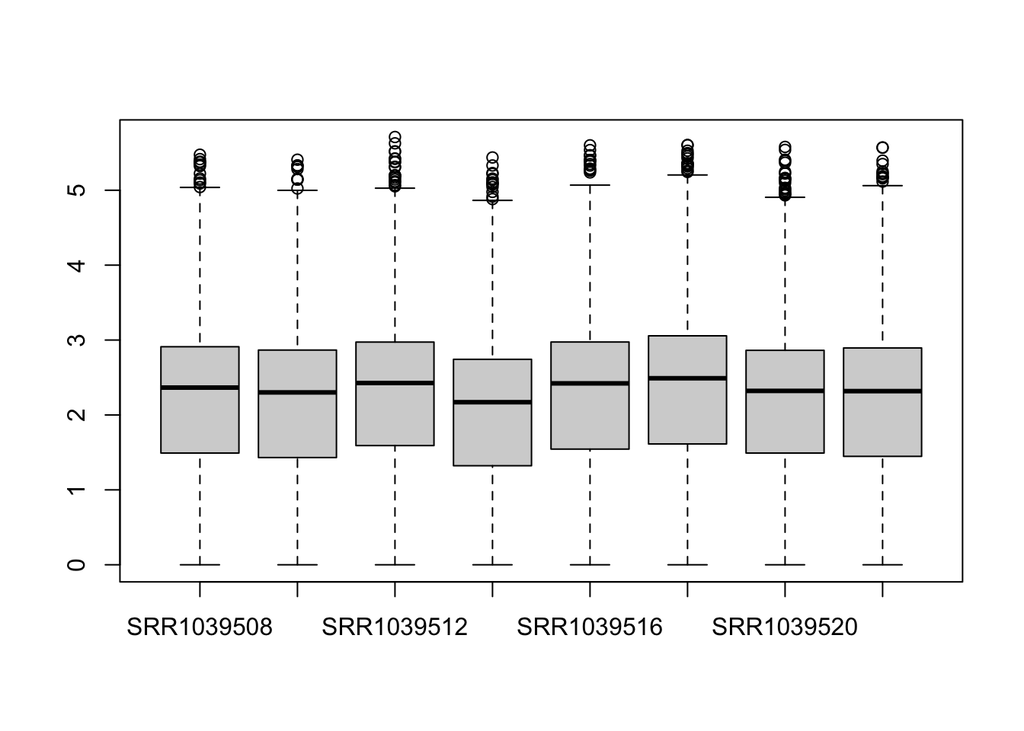

```r
boxplot(log10(counts(dds) + 1))
```

The main function in DESeq2 involves computation of size factors which normalize for differences in sequencing depth among samples. We can also compute these size factors manually, so that the normalized counts are available for plotting:

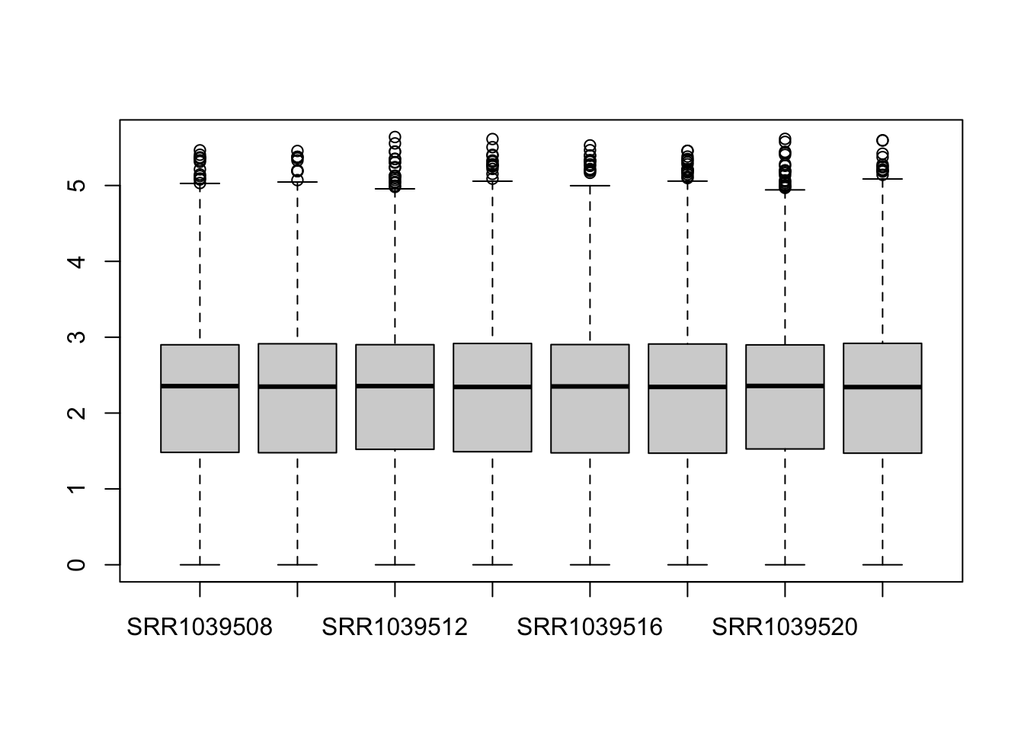

```r
dds <- estimateSizeFactors(dds)
boxplot(log10(counts(dds,normalized=TRUE)+1))
```

7.4.2 Data transformation for EDA

Taking the logarithm of counts plus a pseudocount of 1 is a common transformation, but it tends to inflate the sampling variance of low counts such that it is even larger than biological variation across groups of samples. In DESeq2 we therefore provide transformations which produce log-scale data such that the systematic trends have been removed. Our recommended transformation is the variance-stabilizing transformation, or VST, and it can be called with the vst function:

```r
vsd <- vst(dds)
class(vsd)
```

```
## [1] "DESeqTransform"
## attr(,"package")
## [1] "DESeq2"
```